# CM Lab 2.2 markdown

Eric Stevens

10/2/2018

## 1: Overview

Load required packages:

```r
library(moderndive)
library(tidyverse)
library(skimr)
```

Set the column names:

```r
crimenames <- c("county", "region_name", "region_code",
               "criminals", "public_houses", "school_attendance",
               "worship_attendance")
```

Load the data:

```r
crime <- read_table("https://ohsu-math630-fall-2018.netlify.com/data/beerhall.dat",
                    col_names = crimenames)
```

### $$\hat{criminals} = b_0 + b_1{pubs}$$

## 2: EDA

- Raw Values:

```r
crime
```

```
## # A tibble: 40 x 7
##    county region_name region_code criminals public_houses school_attendan…
##    <chr>  <chr>             <int>     <int>         <int>            <int>
##  1 Middl… South East…           1       200           541              560
##  2 Surrey South East…           1       160           504              630
##  3 Kent   South East…           1       160           552              790
##  4 Sussex South East…           1       147           295              820
##  5 Hants  South East…           1       178           409              990
##  6 Berks  South East…           1       205           568              930
##  7 Herts  South Midl…           1       183           708             1020
##  8 Bucks  South Midl…           1       156           624             1130
##  9 Oxford South Midl…           1       173           463              950
## 10 North… South Midl…           1       132           408             1090
## # ... with 30 more rows, and 1 more variable: worship_attendance <int>
```

- Summary statistics of variables of interest:

```r
crime %>%
  skim()
```

```
## Skim summary statistics
##  n obs: 40
##  n variables: 7
##
## ── Variable type:character ──────────────────────────────────────────────────────
##     variable missing complete  n min max empty n_unique
##       county       0       40 40   4  14     0       40
##  region_name       0       40 40   4  13     0        9
##
## ── Variable type:integer ────────────────────────────────────────────────────────
##            variable missing complete  n   mean     sd  p0   p25   p50
##           criminals       0       40 40 152.9   41.42  66 127   157.5
##       public_houses       0       40 40 374.85 164.97  87 209   407
##         region_code       0       40 40   3.45   2.31   1   1     3
##   school_attendance       0       40 40 957.75 161.44 560 880   965
##  worship_attendance       0       40 40 780.15 172.47 434 654.5 801
##      p75 p100     hist
##   174.25  241 ▂▂▃▅▇▂▃▁
##   490.75  708 ▃▆▂▂▇▅▃▂
##     5       8 ▇▂▃▅▃▁▁▂
##  1082.5  1250 ▂▁▅▆▇▅▇▂
##   912    1136 ▃▃▇▃▇▇▃▂
```

- Get scatter plot of variable of interest vs target.

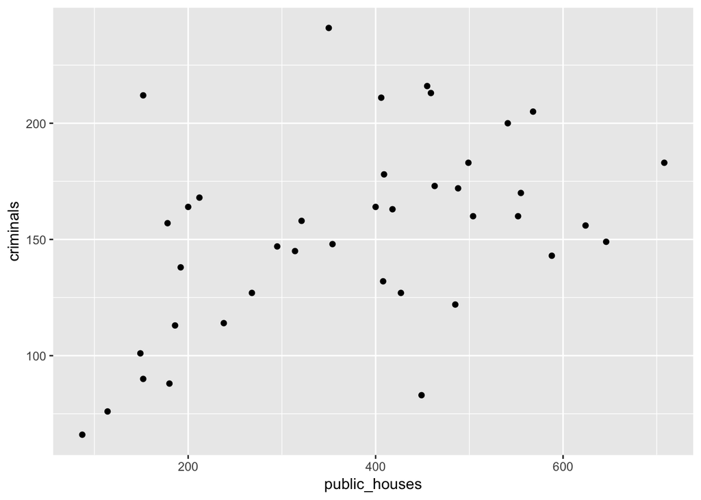

```r
ggplot(crime, aes(public_houses, criminals)) + geom_point()
```

## 3: Simple linear regression

#### Part 1:

Fit linear regression model to the data:

```r
score_model <- lm(criminals ~ public_houses, data = crime)
score_model
```

```
##
## Call:
## lm(formula = criminals ~ public_houses, data = crime)
##
## Coefficients:
##   (Intercept)  public_houses
##      109.3399         0.1162
```

Model the object:

```r
get_regression_table(score_model)
```

```
## # A tibble: 2 x 7
##   term          estimate std_error statistic p_value lower_ci upper_ci
##   <chr>            <dbl>     <dbl>     <dbl>   <dbl>    <dbl>    <dbl>
## 1 intercept      109.       14.8        7.41   0       79.5    139.
## 2 public_houses    0.116     0.036      3.22   0.003    0.043    0.189
```

The equation of the linear regression is as follows:

$$\hat{y} = 109.340 + 0.116{x}$$

#### Part 2:

The values obtained in the linear regression do match the EDA. The interpretation of the of the linear regression model is that there is a positive correlation between the number of public houses and the total number of criminals. To be precise, with a coefficient of 0.116, the regression approximates that for every if you build 10 more public houses you will have one additional criminal. The intercept of 109 implies that even if there were no public houses you would still have 109 criminals.

The graph seems to hint at a stronger correlation between the number of public houses and and criminals than the linear regression does. I think this is a result of using SSE as our function to minimize coupled with the fact that there are a several outliers that change the trend.

## 4 Observed / fitted

#### Part 1:

We obtain information about the residuals using the following code:

```r
regression_points <- get_regression_points(score_model)
regression_points %>% filter(ID==20 | ID==23)
```

```
## # A tibble: 2 x 5
##      ID criminals public_houses criminals_hat residual
##   <int>     <dbl>         <dbl>         <dbl>    <dbl>
## 1    20        66            87          119.    -53.4
## 2    23       241           350          150.     91.0
```

The observed and fitted values for the requested counties are as follows:

[output not shown]

Due to my own beliefs I am in no position to comment on the good reverends ideas of objective morality.

#### Part 2:

Now we filter the results of the regression model for 1) the minimum number of criminals overall, and 2) the largest negative difference between the observed value and the fitted value.

This represents the least number of criminals overall and the county with the least amount of criminals compared to what was predicted.

```r
regression_points %>% filter( criminals == min(criminals) | residual == min(residual))
```

```
## # A tibble: 2 x 5
##      ID criminals public_houses criminals_hat residual
##   <int>     <dbl>         <dbl>         <dbl>    <dbl>
## 1    20        66            87          119.    -53.4
## 2    33        83           449          162.    -78.5
```

```r
crime[20,]
```

```
## # A tibble: 1 x 7
##   county region_name region_code criminals public_houses school_attendan…
##   <chr>  <chr>             <int>     <int>         <int>            <int>
## 1 Cornw… South West…           3        66            87             1050
## # ... with 1 more variable: worship_attendance <int>
```

```r
crime[33,]
```

```
## # A tibble: 1 x 7
##   county region_name region_code criminals public_houses school_attendan…
##   <chr>  <chr>             <int>     <int>         <int>            <int>
## 1 Derby  North Midl…           5        83           449             1210
## # ... with 1 more variable: worship_attendance <int>
```

## 5: Residual analysis

#### Part 1:

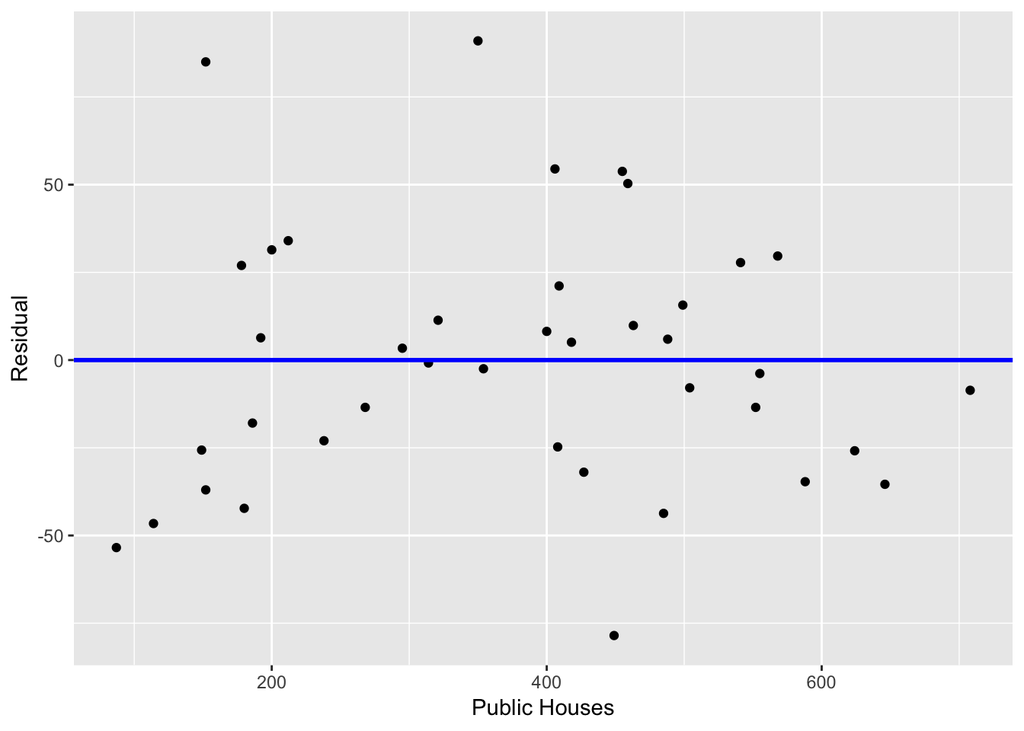

```r
ggplot(regression_points, aes(x = public_houses, y = residual)) +
  geom_point() +
  labs(x = "Public Houses", y = "Residual") +
  geom_hline(yintercept = 0, col = "blue", size = 1)
```

From our scatter plot we can see that there is *no symetric pattern*. This is good because it implies that the linear model is appropriate for the estimation. If there had been a symmetric pattern, we would know that there may be a higher order model that would better capture the relationship we are trying to model.

#### Part 2:

Lets plot the distribution density of the residuals in terms of their magnitude:

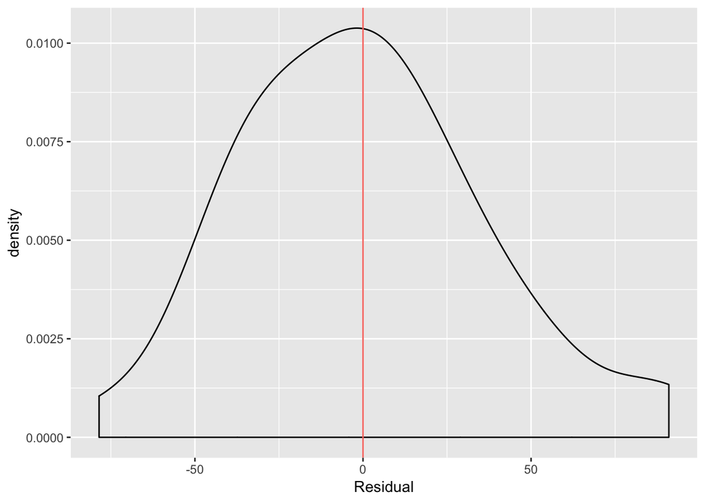

```r
ggplot(regression_points, aes(x = residual)) +
  geom_density() +
  labs(x = "Residual") + geom_vline(data = regression_points, aes(xintercept = 0, color="red")) +
  guides(color=F)
```

From this plot we can see that there is a fairly even distribution across the 0 line. In other words, there were about as many negative residuals as there were positive. There appears to be a higher density of negative residuals near the 0 mark, put the tail of the positive residuals extends further, therefore it appears symmetric.